# Learn R

Anders Swanson

November 1, 2018

# Introduction

## Agenda

1. Background on:
   1. Why we’re here
   2. R, and the Tidyverse
   3. Data Science
2. Helpful Resources
3. Self-guided workshop

## Why are you here?

- Your career (i.e. the PA exam)
- Your curiousity?
- Future of Actuarial Science

## Exam PA - Predictive Analytics

- Required to be an actuary
- New exam representing the shift
- Newest and most different exam
- Prep class is more than $1000?

## Concerns over exam

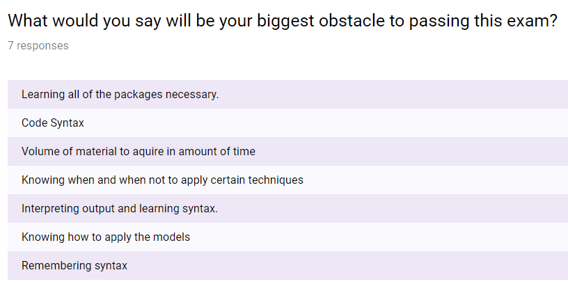

## Why is he here?

**Motivation**

1. Learning R seriously leveled me up
2. I enjoy helping/teaching others.
3. That prep class is stupid expensive.
4. I get to take credit for anything you do in R in the future.

# The R universe

## R History

- S
  - 1976: invented by John Chambers (Bell Labs)
  - 1998: awarded ACM Computing Machinery award
- S-PLUS (commerical S)
  - 1988 Douglas Martin (UW Statistics)
  - most recently owned by TIBCO (on Westlake)
- R (a.k.a. base R)
  - 1995: initial version
  - created by Ross Ihaka & Robert Gentleman (University of Auckland)
  - named after their first names and a play on “S”
- RStudio
  - 2011: JJ Allaire

## Why R

- open-source
- large community
  - academics
  - over 10,000 packages on CRAN
- dataframe object
- “vectorized”
- built in libraries for:
  - stats,
  - graphics, and
  - linear algebra.

# Data Science

## Core Tenants Data Science

- Exploratory Data Analysis
- Reproducible Research
- Big Data
- Machine Learning

## Exploratory Data Analysis

- EDA vs. scientific method

## Reproducible Research

- reproducible, legible, shareable results
- Harvard Econ Austerity Paper

# The Tidyverse

## The R heir-apparent

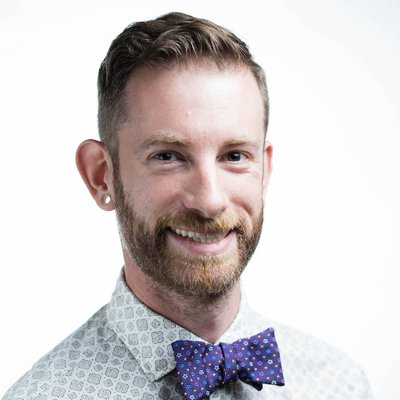

Hadley Wickham